# Primeiro Projeto de Data Science

Marcus Nunes

6/9/2018

# Introdução

1. Mostrar que data science não é um bicho de sete cabeças

# Preparação do Software

Quem já possui os programas R e RStudio instalados em seu computador pode pular esta parte do tutorial.

Há diversos programas disponíveis para fazer data science. Os dois principais são R e python. Este tutorial foi escrito pensado na linguagem R para ser rodado. Particularmente, prefiro o R ao python, pois a sintaxe dele é, para mim, mais fácil de entender. Mas isto é gosto pessoal. Tudo o que foi feito aqui pode ser adaptado e realizado em qualquer outra linguagem que o leitor prefira, como python, julia ou matlab, por exemplo.

Se o seu computador não possua o R e o RStudio instalado, clique nos links abaixo e instale-os.

- [R](http://cran.fiocruz.br/): este programa é o cerne da análise. É ele que vai realizar os cálculos e plotar os gráficos da análise.
- [RStudio](https://www.rstudio.com/products/rstudio/download/): por padrão, a interface do R não é muito amigável de utilizar. É necessário melhorá-la para que ela fique mais interativa e, consequentemente, nossa produtividade aumente. Portanto, o RStudio serve para melhorar a utilização do R, deixando-a mais dinâmica.

Com o script aberto, rode o comando abaixo e aguarde. Vários arquivos serão baixados e o R vai informando o progresso da instalação.

```r
install.packages(c("tidyverse", "corrplot", "GGally", "caret", "rpart", "rpart.plot"), dependencies=TRUE)
```

Este passo pode demorar um pouco, dependendo da velocidade da sua conexão com a internet.

Com tudo preparado, é hora de começar a análise.

# Obtenção dos Dados

Obter dados para análise é algo trivial hoje em dia. Existem diversos sites que disponibilizam todo tipo de dados para as mais diversas tarefas. Abaixo eu listo algumas das minhas fontes preferidas para buscar dados abertos, colocadas mais ou menos em ordem de preferência e importância:

- [Kaggle](https://kaggle.com/datasets/): Acredito que este seja, atualmente, o maior site sobre machine learning. Possui muitos conjuntos de dados disponíveis, nas mais variadas áreas. Além dos dados, há diversos projetos de machine learning já realizados nele, fazendo com que seja uma fonte quase inesgotável de informação.
- [UCI Machine Learning Repository](http://archive.ics.uci.edu/ml/): Este é o pai do Kaggle. Na época em que fiz meu primeiro curso de data mining, ainda durante meu doutorado no longínquo ano de 2010, este site era minha fonte principal de conjuntos de dados para classificação e clusterização.
- [Instituto Brasileiro de Geografia e Estatística (IBGE)](http://downloads.ibge.gov.br/): O site do IBGE disponibiliza informações sobre os cendos, PNAD e tudo mais que o IBGE trabalha.
- [Banco Central do Brasil](http://www4.bcb.gov.br/pec/series/port/aviso.asp): Dados históricos sobre inflação, câmbio, exportações e mais.
- [Portal Brasileiro de Dados Abertos](http://dados.gov.br): Informações oficiais do governo brasileiro sobre mapas, orçamento da união, aviação, dentre outros assuntos.
- [Portal da Transparência](http://www.transparencia.gov.br/): Dados do executivos brasileiro, como salários, pagamentos de programas sociais e muito mais.
- [Dados Abertos da Câmara dos Deputados](http://www2.camara.leg.br/transparencia/cota-para-exercicio-da-atividade-parlamentar/dados-abertos-cota-parlamentar): Informações a respeitos dos gastos da Câmara. Embora sejam abertos, é um pouco difícil de acessar para quem não entende de tecnologias como xml e json. Por isso, escrevi um [pacote no R](https://github.com/mnunes/reembolsos/) que organiza estes dados de maneira a torná-los mais acessíveis.
- [Gene Expression Omnibus (GEO)](http://www.ncbi.nlm.nih.gov/geo/): Fonte de dados genéticos. É possível encontrar dados de artigos científicos e reproduzir os resultados obtidos pelos autores.
- [The home of the U.S. Government’s open data](http://www.data.gov/): Site de dados abertos do governo norte-americano. Possui milhares de conjuntos de dados.
- [IMDb](http://www.imdb.com/interfaces): Dados abertos que o [IMDb](http://imdb.com/), site especializado em filmes e séries de TV, disponibiliza. Vale muito pelas avaliações que os usuários do site dão para as produções audiovisuais cadastradas no site.
- [The Last.fm Dataset | Million Song Dataset](http://labrosa.ee.columbia.edu/millionsong/lastfm): Informações sobre milhões de músicas tocadas pelos usuários do last.fm, rede social focada em música.
- [Economic Time Series Page](http://www.economagic.com/): Dados de séries temporais econométricas.
- [Time Series Data Library](https://datamarket.com/data/list/?q=provider:tsdl): Fonte excelente para quem procura dados de séries temporais, sejam eles econométricos ou não.

Além destas fontes de terceiros, eu mantenho uma lista de favoritos online, locais em que encontrei fontes interessantes para dados. Venho fazendo isto desde 2007. Os links são os seguintes:

- https://pinboard.in/u:grandeabobora/t:datasets/
- https://pinboard.in/u:grandeabobora/t:database/

Caso alguma fonte de dados óbvia tenha faltado, comente aí embaixo que eu atualizo o post com ela.

# Análise Exploratória dos Dados

Como não poderia deixar de ser, a primeira parte de um projeto de data science segue a mesma lógica de um projeto de análise etatística de dados. Precisamos fazer a análise exploratória a fim de entender o conjunto de dados com o qual estamos trabalhando.

O conjunto de dados que vou baixar se chama [Iris Flower Dataset](https://en.wikipedia.org/wiki/Iris_flower_data_set). Por ser multivariado e com um número razoável de observações, este conjunto é bastante famoso na literatura estatística. Até mesmo Fisher já trabalhou conceitos de análise multivariada com estes dados.

Seu nome é Iris porque foram coletadas observações de 150 espécimes de 3 flores do gênero iris: Iris setosa, Iris versicolor e Iris virginica.

Embora este conjunto de dados esteja disponível em qualquer instalação do R, este tutorial vai mostrar como obter dados diretamente da internet. Então é isto que faremos abaixo, baixando este conjunto iris diretamente do site do [UCI Machine Learning Repository](http://archive.ics.uci.edu/ml/) e processando-o na sequêncai para análise.

```r
# definir o endereco do conjunto de dados e baixa-lo

url <- "https://archive.ics.uci.edu/ml/machine-learning-databases/iris/iris.data"

iris        <- read.csv(url, header=FALSE)
names(iris) <- c("c_sepala", "l_sepala", "c_petala", "l_petala", "especie")

# remover a string 'Iris-' do inicio de cada tipo de especie

iris$especie <- as.factor(gsub("Iris-", "", iris$especie))

# estatistica descritiva basica

summary(iris)
```

```
##     c_sepala        l_sepala        c_petala        l_petala
##  Min.   :4.300   Min.   :2.000   Min.   :1.000   Min.   :0.100
##  1st Qu.:5.100   1st Qu.:2.800   1st Qu.:1.600   1st Qu.:0.300
##  Median :5.800   Median :3.000   Median :4.350   Median :1.300
##  Mean   :5.843   Mean   :3.054   Mean   :3.759   Mean   :1.199
##  3rd Qu.:6.400   3rd Qu.:3.300   3rd Qu.:5.100   3rd Qu.:1.800
##  Max.   :7.900   Max.   :4.400   Max.   :6.900   Max.   :2.500
##        especie
##  setosa    :50
##  versicolor:50
##  virginica :50
##
##
##
```

Com isso, percebemos que temos um conjunto de dados formado por cinco variáveis. Quatro destas variáveis são quantitativas e uma é categórica. As variáveis são

- c_sepala: comprimento da sépala das flores
- l_sepala: largura da sépala das flores
- c_petala: comprimento da pétala das flores
- l_petala: largura da pétala das flores
- especie: espécie da flor

Há diversas atividades que podem ser feitas com este conjunto de dados. O que farei aqui é uma tarefa de classificação. Vou ajustar um modelo que vai prever a espécie da planta baseado nas quatro dimensões de cada uma delas.

É importante qual o objetivo do nosso primeiro projeto de data science logo no seu começo. Assim, podemos direcionar nossas análises diretamente para este fim, sem perder tempo realizando atividades que não contribuem para o nosso objetivo.

Com o objetivo definido, vamos fazer algumas análises básicas. A primeira delas é verificar se existe correlação entre as nossas variáveis. Perceba que vou retirar a coluna 5 desta análise porque ela não é uma variável quantitativa.

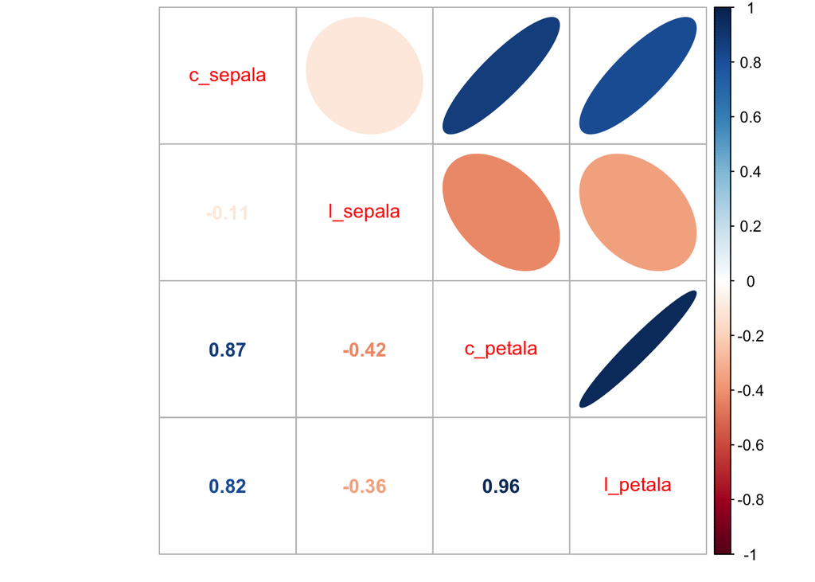

```r
library(corrplot)
correlacao <- cor(iris[, -5])

corrplot.mixed(correlacao, upper="ellipse")
```

Podemos perceber que existem valores razoáveis de correlação entre algumas das combinações de variáveis. Em particular, entre o comprimento e a largura da pétala. Podemos visualizar isto em um gráfico de dispersão:

```r
library(tidyverse)
```

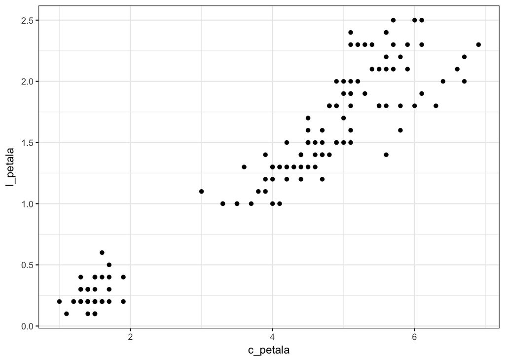

```r
theme_set(theme_bw())

ggplot(iris, aes(x=c_petala, y=l_petala)) +
  geom_point()
```

Embora já vejamos a relação que existe entre as variáveis comprimento e largura da pétala, podemos colocar mais informações neste gráfico. Por exemplo, podemos colorir os pontos de acordo com a espécie da planta.

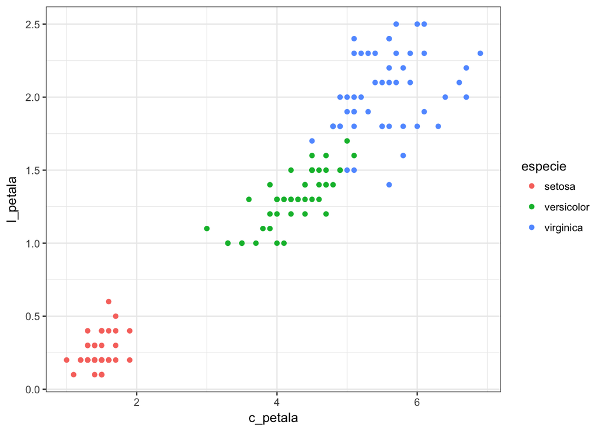

```r
ggplot(iris, aes(x=c_petala, y=l_petala, colour=especie)) +
  geom_point()
```

Agora podemos ver que o grupo de flores da espécie setosa está bastante separado dos demais. Esta é uma informação importante, pois queremos construir um algoritmo de classificação de espécies. Por outro lado, perceba que as espécies versicolor e virginica estão quase se confundindo uma com a outra. Isto pode acabar prejudicando um pouco nosso algoritmo de classificação.

A fim de verificar como é o comportamento das outras variáveis, podemos extender o gráfico anterior para todas a combinações de variáveis neste conjunto de dados. Em vez de repetirmos manualmente o código, vamos utiliar a função `ggpairs` do pacote `GGally`:

```r
library(GGally)
```

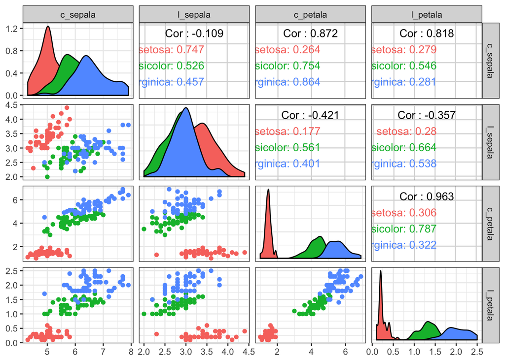

```r
ggpairs(iris[, -5], aes(colour = iris$especie))
```

Veja que agora temos muitas informações sobre nossos dados. Para quem já tem alguma experiência em análise de dados, o que vemos é o seguinte:

- Diagonal principal: estimativas da função densidade de cada uma das quatro variáveis, de acordo com a espécie de flor
- Triângulo inferior: gráficos de dispersão das variáveis do conjunto de dados, duas a duas
- Triângulo superior: correlação total entre as variáveis e correlação dentro de cada grupo

Com a análise exploratória dos dados terminada, podemos partir para o ajuste do modelo.

# Ajuste do Modelo

Há uma infinidade de opçõess quando falamos de ajuste de modelos de classificação. Neste tutorial vou utilizar o [Random Forest (link em inglês, pois a Wikipedia em Português ainda não possui um verbete sobre este assunto)](https://en.wikipedia.org/wiki/Random_forest), que é poderoso o suficiente, além de ter convergência rápida e ser de fácil utilização.

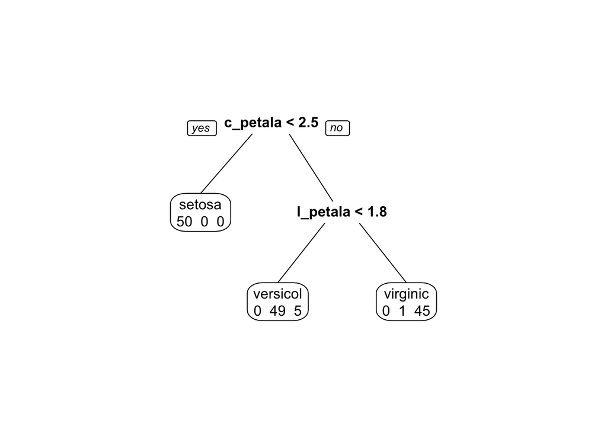

```r
library(rpart)
library(rpart.plot)
modelo <- rpart(especie ~ ., method="class", data=iris)
prp(modelo, extra=1)
```

Perceba que é feita uma pergunta em cada nó da árvore. O resultado da pergunta determina se outra pergunta será feita ou se a árvore chegou ao fim e a classificação foi terminada. Além disso, o erro de classificação é determinado ao final da árvore.

Uma Random Forest (ou Floresta Aleatória) é a combinação de centenas de árvores de classificação. Este resultado segue do fato de que a combinação de diversos modelos diferentes é melhor do que um modelo sozinho.

## Conjuntos de Treino e Teste

Um problema que surge no ajuste de modelos de classificação e regressão é o [sobreajuste](https://pt.wikipedia.org/wiki/Sobreajuste). O sobreajuste ocorre quando o modelo se ajusta muito bem aos dados, se tornando ineficaz para prever observações novas.

O gráfico abaixo ilustra este conceito no contexto de um modelo de classificação.

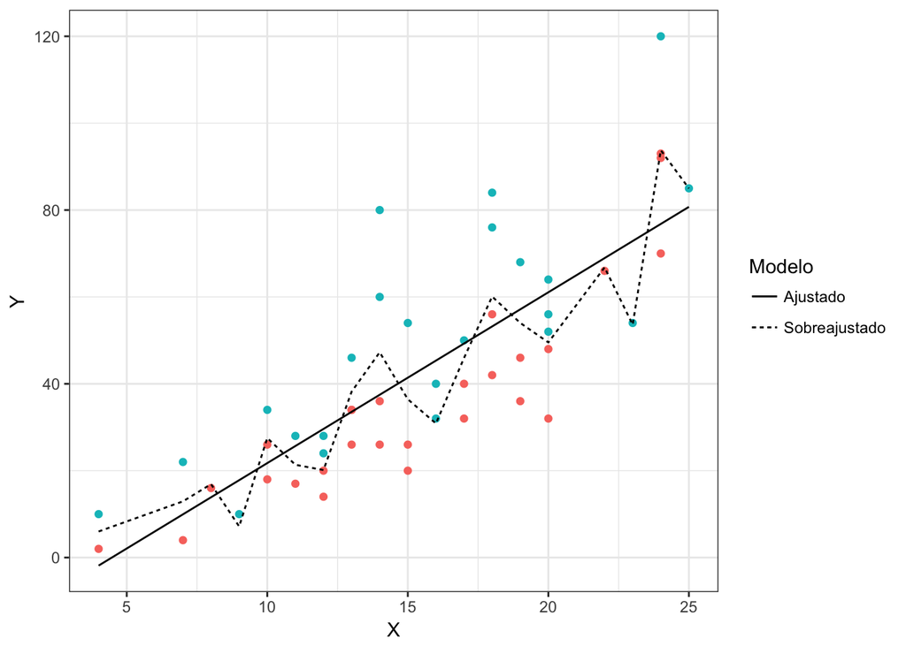

Note como o modelo sobreajustado acompanha os dados muito mais de perto, enquanto o modelo ajustado segue a tendência geral de separação dos pontos. A desvantagem de ter um modelo que acompanhe os dados de maneira muito próxima é a perda de generalidade. Este tipo de modelo funciona muito bem para um conjunto de dados específico, mas vai se comportar muito mal se novas observações forem coletadas.

Uma forma de evitar este problema é dividindo aleatoriamente o conjunto de dados original em duas partes mutuamente exclusivas. Uma destas partes é chamada de conjunto de treino e, a outra, conjunto de teste. A ideia por trás disso é ajustar o modelo aos dados de treinamento e simular a entrada de novas observações através do conjunto de teste. Assim, é possível verificar quão bem ou quão mal o modelo ajustado está se compotando ao prever observações que não foram utilizadas em seu ajuste.

Para fazer isto no R utilizamos a função `createDataPartition` do pacote `caret`.

```r
library(caret)
# definir 75% dos dados para treino, 25% para validacao

trainIndex  <- createDataPartition(iris$especie, p=0.75, list=FALSE)
iris_treino <- iris[ trainIndex, ]
iris_teste  <- iris[-trainIndex, ]
```

Ao fazer `iris_treino <- iris[ trainIndex, ]` eu estou dizendo que o conjunto de dados `iris_treino` vai ter as linhas de `iris` com os números presentes em `trainIndex`. De modo análogo, `iris_teste <- iris[-trainIndex, ]` diz que o conjunto de dados `iris_teste` **não** vai ter as linhas de `iris` com os números presentes em `trainIndex`

Agora tenho dois data frames novos em minha área de trabalho. 75% das observações estão no conjunto de treino e 25% no conjunto de teste. Esta divisão é arbitrária. Normalmente, recomenda-se que o conjunto de treino tenha de 70% a 80% das observações. O restante das observações irá fazer parte do conjunto de teste.

Ocorre que esta divisão dos dados em dois grupos tem uma desvantagem. Isto acaba fazendo com que tenhamos menos dados para ajustar o modelo. E, com menos dados para ajustar o modelo, menos informação temos. Com menos informação, pior ficará nosso modelo. Uma maneira de reduzir este efeito é através da validação cruzada.

## Validação Cruzada

A [validação cruzada](https://pt.wikipedia.org/wiki/Valida%C3%A7%C3%A3o_cruzada) é mais um método utilizado para evitar sobreajuste no modelo. A ideia é ajustar diversas vezes o mesmo modelo em partições (conjuntos mutuamente exclusivos) do conjunto de treinamento original. Neste exemplo eu vou utilizar um método chamado validação cruzada $k$-fold_.

Esta técnica consiste em cinco passos:

1. Separar o conjunto de treinamento em $k$ *folds* (ou partições)
2. Ajustar o modelo em $k-1$ *folds*
3. Testar o modelo no *fold* restante
4. Repetir os passos 2 e 3 até que todos os *folds* tenham sido utilizados para teste
5. Calcular a acurácia do modelo

Entretanto, precisamos definir o número de *folds* a serem utilizados na validação cruzada. Em geral, a literatura sugere que de 5 a 10 *folds* sejam usados. O desempenho dos algoritmos não melhora de maneira considerável se aumentarmos muito o número de *folds*.

Dependendo do tamanho do conjunto de dados, é possível que muitos *folds* acabem deixando-nos sem observações para os conjuntos de teste dentro da validação cruzada. Por este motivo, é sempre bom controlar este parâmetro de acordo com o conjunto de dados que estamos estudando.

Com estas técnicas definidas, podemos finalmente passar para o ajuste do modelo.

## Ajuste do Modelo

Como dito anteriormente, vamos ajustar um modelo chamado Random Forest aos dados das flores. Para realizar este ajuste precisamos criar os conjuntos de treino e teste e fazer a validação cruzada do modelo a ser ajustado. Como já criamos os conjuntos de treino e teste anteriormente, apenas precisamos nos preocupar com a validação cruzada do modelo.

Felizmente, o pacote `caret` já possui o algoritmo da validação cruzada implementado. Só precisamos ser explícitos no ajuste do modelo para que este método seja utilizado.

O `caret` utiliza duas funções para ajustar modelos aos dados, chamdas `train` e `trainControl`. Basicamente, a função `trainControl` estabelece os parâmetros utilizados no ajuste do modelo. Abaixo estou exemplificando como definir que desejamos fazer validação cruzada com 5 *folds*.

```r
fitControl <- trainControl(method = "cv",
                           number = 5)
```

Com os parâmetros da validação cruzada definidos, podemos partir para a o ajuste em si.

```r
ajuste_iris <- train(especie ~ .,
                     data = iris_treino,
                     method = "rf",
                     importance = TRUE,
                     trControl = fitControl)
```

Note que defino várias coisas com a função `train`:

- `especie ~ .` é a notação de fórmula do R, aquele mesma que se utiliza para se ajustar modelos de regressão linear com a função `lm`. Neste exemplo eu estou dizendo que quero prever `especie` em função de todas as outras variáveis do conjunto de dados.
- `data = iris_treino` informa para o R em qual conjunto de dados ele deve procurar as variáveis presentes na fórmula definida acima
- `method = "rf"` diz que vou ajustar um modelo do tipo Random Forest. Uma grande vantagem de usar o pacote `caret` é poder aprender uma sintaxe apenas e poder ajustar centenas de algoritmos diferentes, apenas mudando o argumento `method` da função `train`.
- `importance = TRUE` é um argumento opcional que nos permitirá, posteriormente, fazer seleção de variáveis
- `trControl = fitControl` define as opções da validação cruzada

Para saber o resultado do ajuste, basta chamar o objeto ajuste_iris:

```r
ajuste_iris
```

```
## Random Forest
##
## 114 samples
##   4 predictor
##   3 classes: 'setosa', 'versicolor', 'virginica'
##
## No pre-processing
## Resampling: Cross-Validated (5 fold)
## Summary of sample sizes: 93, 90, 91, 91, 91
## Resampling results across tuning parameters:
##
##   mtry  Accuracy   Kappa
##   2     0.9734472  0.9601089
##   3     0.9734472  0.9601089
##   4     0.9734472  0.9601089
##
## Accuracy was used to select the optimal model using the largest value.
## The final value used for the model was mtry = 2.
```

- $a$: verdadeiro positivo
- $b$: falso negativo
- $c$: falso positivo
- $d$: verdadeiro negativo

Assim, temos as seguintes medidas para avaliar o quão boa foi nossa predição:

$$\textrm{Accuracy} = \frac{a+d}{a+b+c+d}$$

e

$$Kappa:
\begin{align*}
p_{\mbox{Sim}} &= \frac{a+b}{a+b+c+b} \times \frac{a+c}{a+b+c+b} \\
p_{\mbox{Não}} &= \frac{c+d}{a+b+c+b} \times \frac{b+d}{a+b+c+b} \\
p_e &= p_{\mbox{Sim}} + p_{\mbox{Não}} \\
\kappa &= \frac{p_0-p_e}{1-p_e}
\end{align*}$$

# Ideias para Novos Projetos